# Character data visualisation

```python
import datetime as dt
import math
import matplotlib.pyplot as plt
import matplotlib.ticker as ticker
import numpy as np
import pandas as pd
```

```python
df = pd.read_csv("./datasets/characters.csv")
date_format = "%Y-%m-%d"
```

```python
def label_age(row):
    if row["body"] == "loli":
        return "child"
    if row["body"] == "boy" or row["body"] == "girl" or row["body"] == "boy/girl":
        return "teenage"
    if row["body"] == "male" or row["body"] == "lady":
        return "adult"

df["age"] = df.apply(lambda row: label_age(row), axis=1)

# Used for stretching all categories to the right
max_date = dt.datetime.strptime(df["release"].max(), date_format)
```

## Simple visualisation

Pie charts on the left show how characters are currently distributed within different categories (or how they were the last time when the dataset was updated). Graphs on the right show how the number of characters in each category changed over time.

```python
def simple_visualisation(column):
    fig, ax = plt.subplots(1, 2, figsize=(12, 5), gridspec_kw={"width_ratios": [3, 5]})
    fig.suptitle(f"Playable character distribution by {column}", fontsize=16)
    ax[0].set_title("Current", fontweight="bold", pad=20)
    ax[1].set_title("Historical", fontweight="bold", pad=20)

    # Only display whole values on the step graph y axis
    ax[1].yaxis.set_major_locator(ticker.MaxNLocator(integer=True))

    group_sizes = df.groupby(column, as_index=False).size()

    ax[0].pie(group_sizes["size"], labels=group_sizes[column], autopct="%1.1f%%")

    for column_val in group_sizes[column]:
        column_val_by_date = df[getattr(df, column) == column_val].groupby("release").size()

        for date in reversed(column_val_by_date.axes[0]):
            column_val_by_date[date] = column_val_by_date[column_val_by_date.axes[0] <= date].values.sum()

        x_axis = list(map(dt.datetime.strptime, column_val_by_date.axes[0], len(column_val_by_date.axes[0]) * [date_format]))
        y_axis = column_val_by_date.values.tolist()

        # This should stretch all categories to the right
        if (x_axis[len(x_axis) - 1] < max_date):
            x_axis.append(max_date)
            y_axis.append(y_axis[len(y_axis) - 1])

        ax[1].step(x_axis, y_axis, label=column_val, marker="o", markersize=4, where="post")

    fig.tight_layout()
    plt.show()

    print(group_sizes)
```

### Categorised by sex

Since traveller's sex is selected by the player, he or she is listed in a separate category.

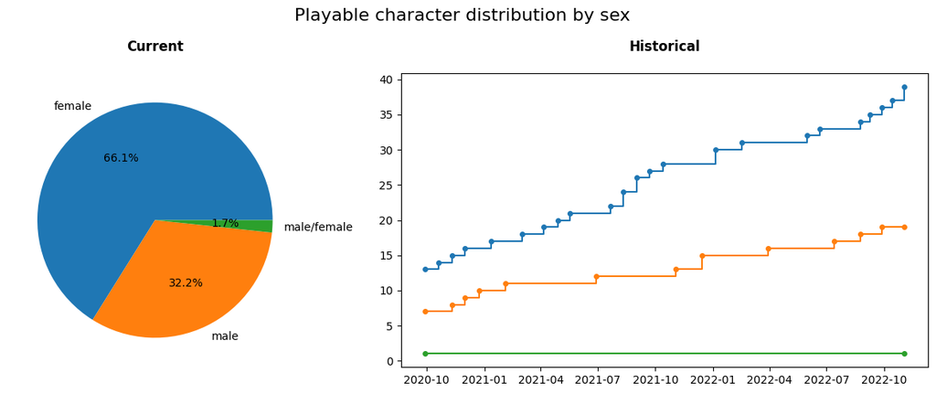

```
           sex  size
0       female    39
1         male    19
2  male/female     1
```

```python
simple_visualisation("sex")
```

## Categorised by age

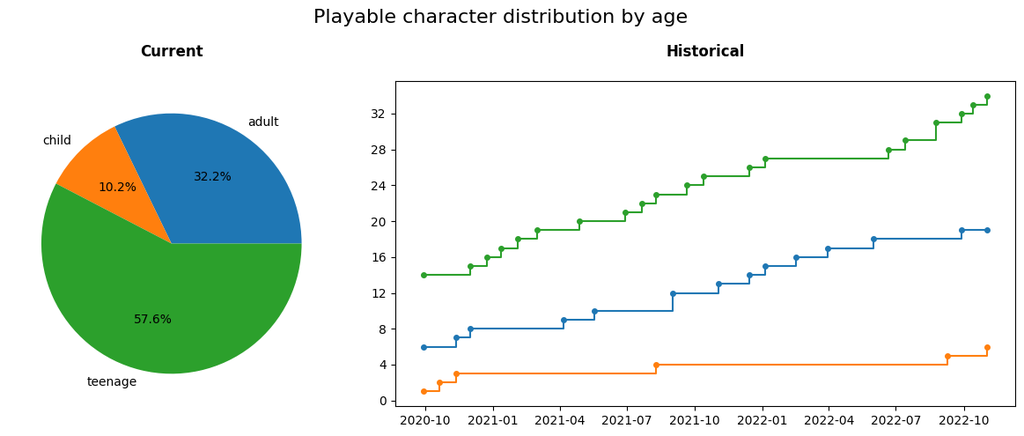

```
       age  size
0    adult    19
1    child     6
2  teenage    34
```

```python
simple_visualisation("age")
```

### Categorised by body type

All playable characters in Genshin Impact use one of the five body templates with custom clothes and hair added on top. Those body templates are (as named in game files):

| Body type | Description | Example characters |
| --- | --- | --- |
| Boy | Teenage male | Albedo, Gorou, Kazuha |
| Male | Young male | Zhongli, Itto, Diluc |
| Loli | Child female | Klee, Sayu, Diona |
| Girl | Teenage female | Sucrose, Ayaka, Kokomi |
| Lady | Young female | Jean, Shogun, Sara |

Since traveller's sex is chosen by the player, he or she is listed in a separate category.

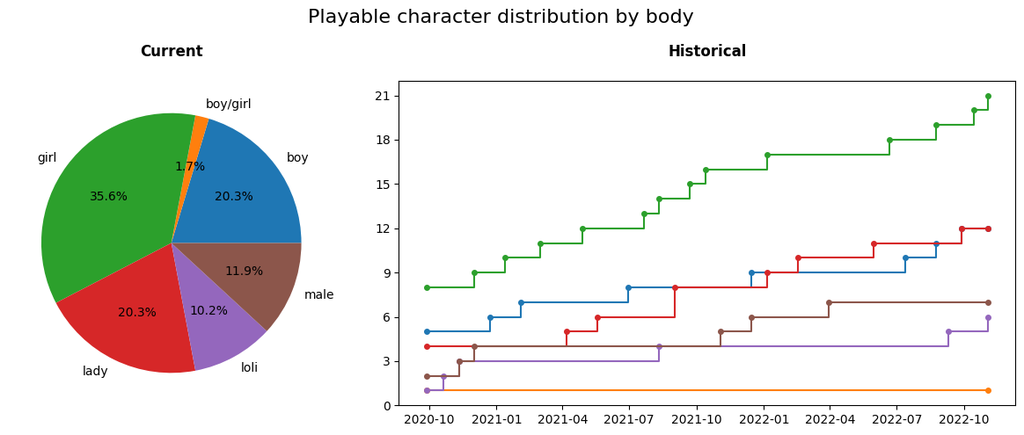

```
       body  size
0       boy    12
1  boy/girl     1
2      girl    21
3      lady    12
4      loli     6
5      male     7
```

```python
simple_visualisation("body")
```

### Categorised by wielded weapon

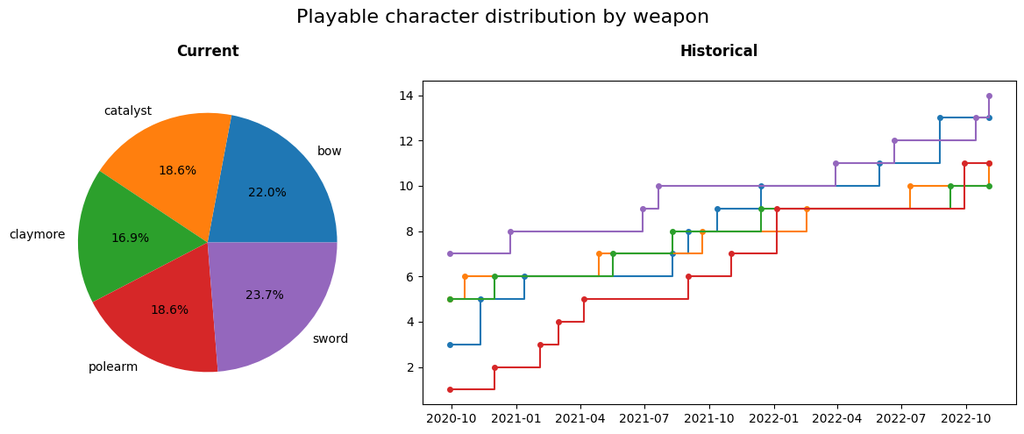

```
     weapon  size
0       bow    13
1  catalyst    11
2  claymore    10
3   polearm    11
4     sword    14
```

```python
simple_visualisation("weapon")
```

### Categorised by home region

Traveller and Aloy do not have a home region within Teyvat, so they are listed in a separate category.

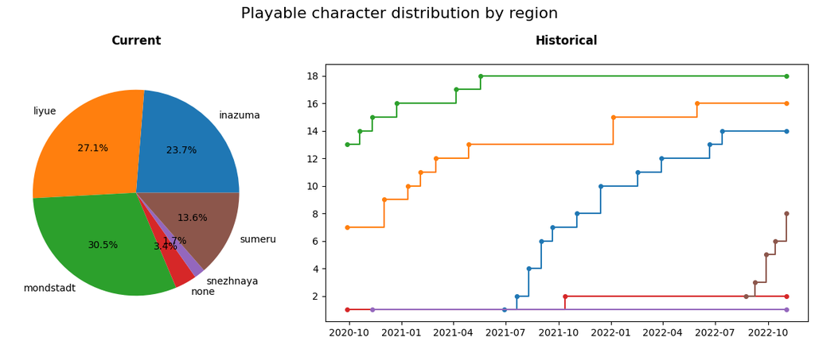

```
      region  size
0    inazuma    14
1      liyue    16
2  mondstadt    18
3       none     2
4  snezhnaya     1
5     sumeru     8
```

```python
simple_visualisation("region")
```

### Categorised by vision element

Traveller technically doesn't have a vision, and his or her element can be switched, so there's a separate category for him or her.

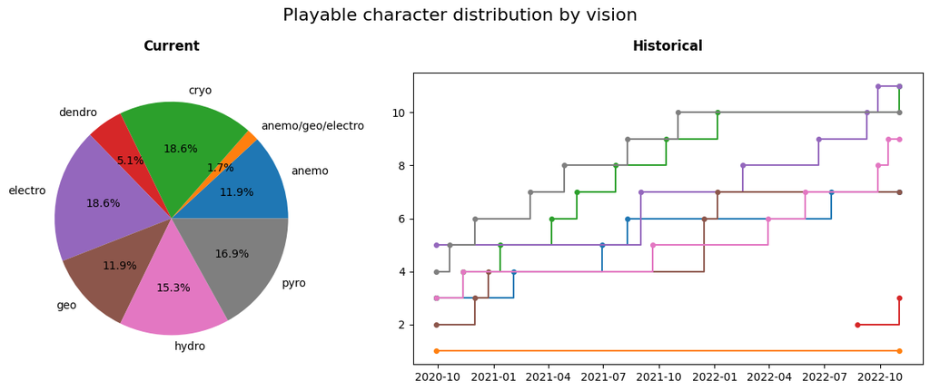

```
              vision  size
0              anemo     7
1  anemo/geo/electro     1
2               cryo    11
3             dendro     3
4            electro    11
5                geo     7
6              hydro     9
7               pyro    10
```

```python
simple_visualisation("vision")
```

### Categorised by quality

The number of ☆☆☆☆☆ characters vs the number of ☆☆☆☆ characters.

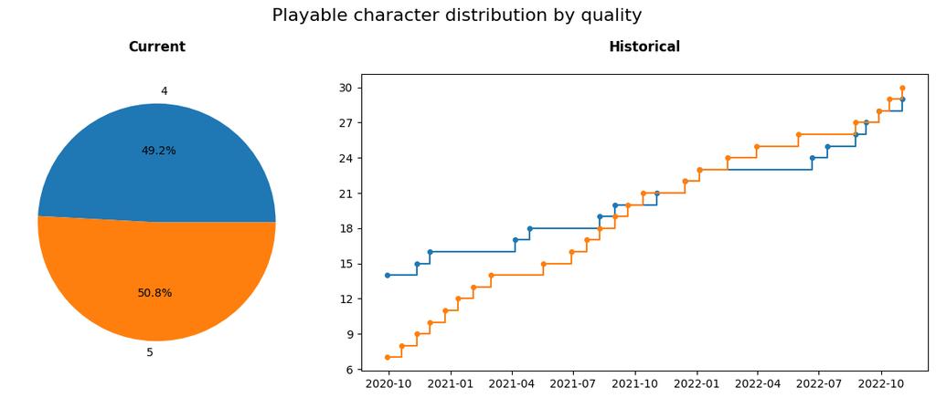

```
   quality  size
0        4    29
1        5    30
```

```python
simple_visualisation("quality")
```

## Divided visualisation

Comparing category distribution between different categories.

```python
def divided_visualisation(column, divided_by):
    divisions = df[divided_by].unique()

    if len(divisions) <= 3:
        nrows = 1
        ncols = len(divisions)
    else:
        ncols = 3
        nrows = math.ceil(len(divisions) / ncols)

    fig, ax = plt.subplots(nrows, ncols, figsize=(6 * ncols, 5 * nrows))

    if nrows == 1:
        for i, division in enumerate(divisions):
            ax[i].set_title(division, fontweight="bold", pad=20)
            group_sizes = df[getattr(df, divided_by) == division].groupby(column, as_index=False).size()
            ax[i].pie(group_sizes["size"], labels=group_sizes[column], autopct="%1.1f%%")
    else:
        for x, division in enumerate(divisions):
            i = int(x / ncols)
            j = x % ncols

            ax[i, j].set_title(division, fontweight="bold", pad=20)
            group_sizes = df[getattr(df, divided_by) == division].groupby(column, as_index=False).size()
            ax[i, j].pie(group_sizes["size"], labels=group_sizes[column], autopct="%1.1f%%")

        j += 1
        while j < ncols:
            ax[i, j].set_visible(False)
            j += 1

    fig.suptitle(f"Playable character distribution by {column} divided by {divided_by}", fontsize=16)
    fig.tight_layout()
    plt.show()
```

### Categorised by wielded weapon, compared between sexes

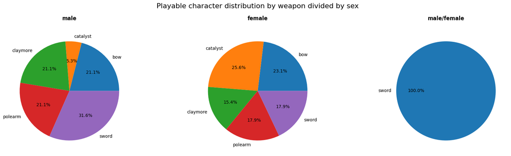

```python
divided_visualisation("weapon", "sex")
```

### Categorised by wielded weapon, compared between ages

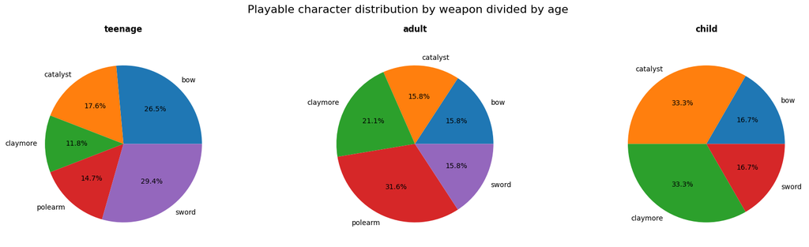

```python
divided_visualisation("weapon", "age")
```

### Categorised by age, compared between sexes

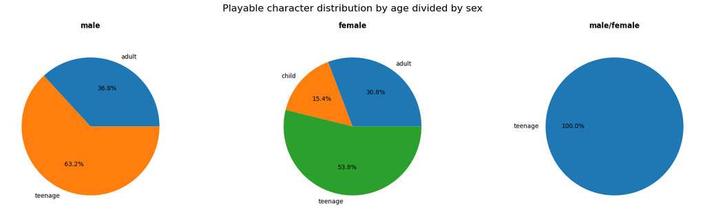

```python
divided_visualisation("age", "sex")
```

### Categorised by vision, compared between sexes

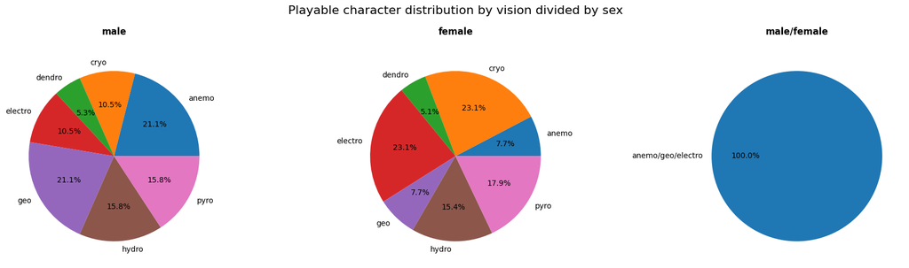

```python
divided_visualisation("vision", "sex")
```

### Categorised by age, compared between vision elements

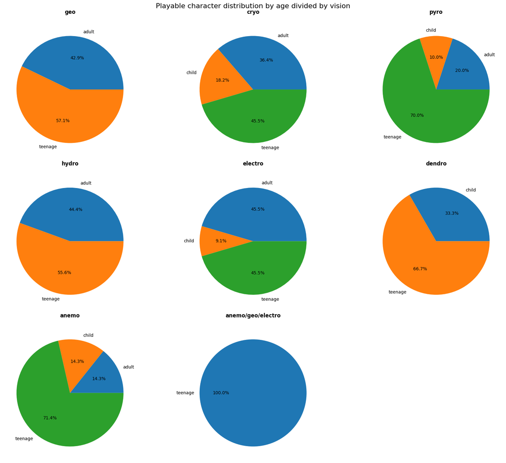

```python
divided_visualisation("age", "vision")
```

### Categorised by vision, compared between wielded weapons

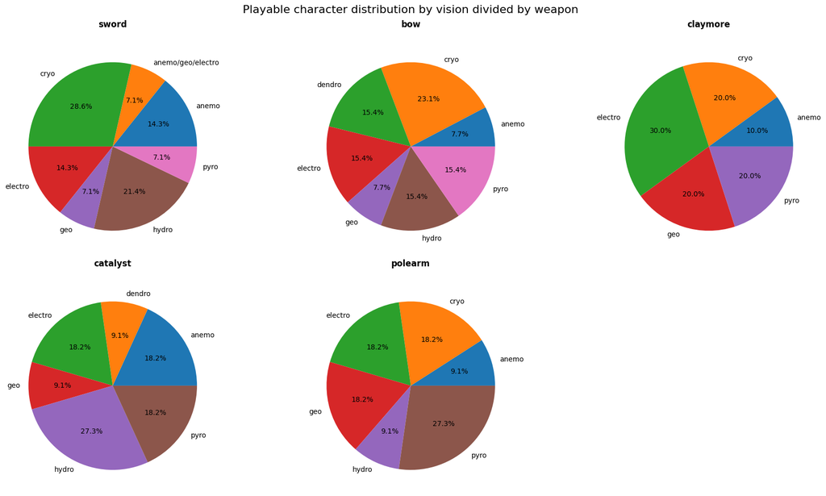

```python
divided_visualisation("vision", "weapon")
```

### Categorised by wielded weapon, compared between regions

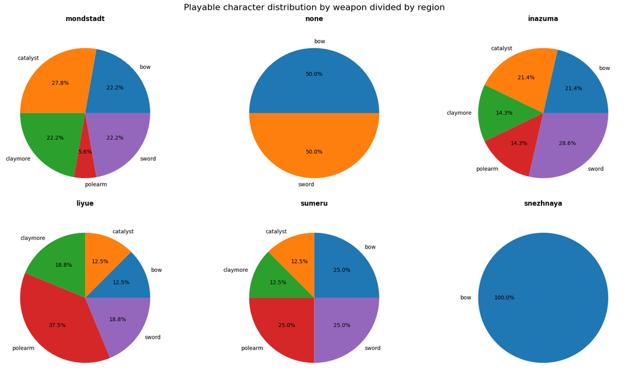

```python
divided_visualisation("weapon", "region")
```

### Categorised by home region, compared between quality

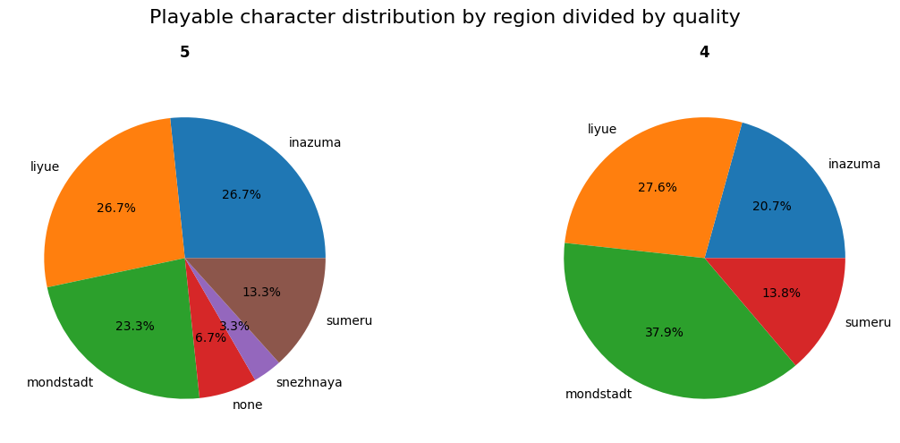

```python
divided_visualisation("region", "quality")
```

### Categorised by quality, compared between vision elements

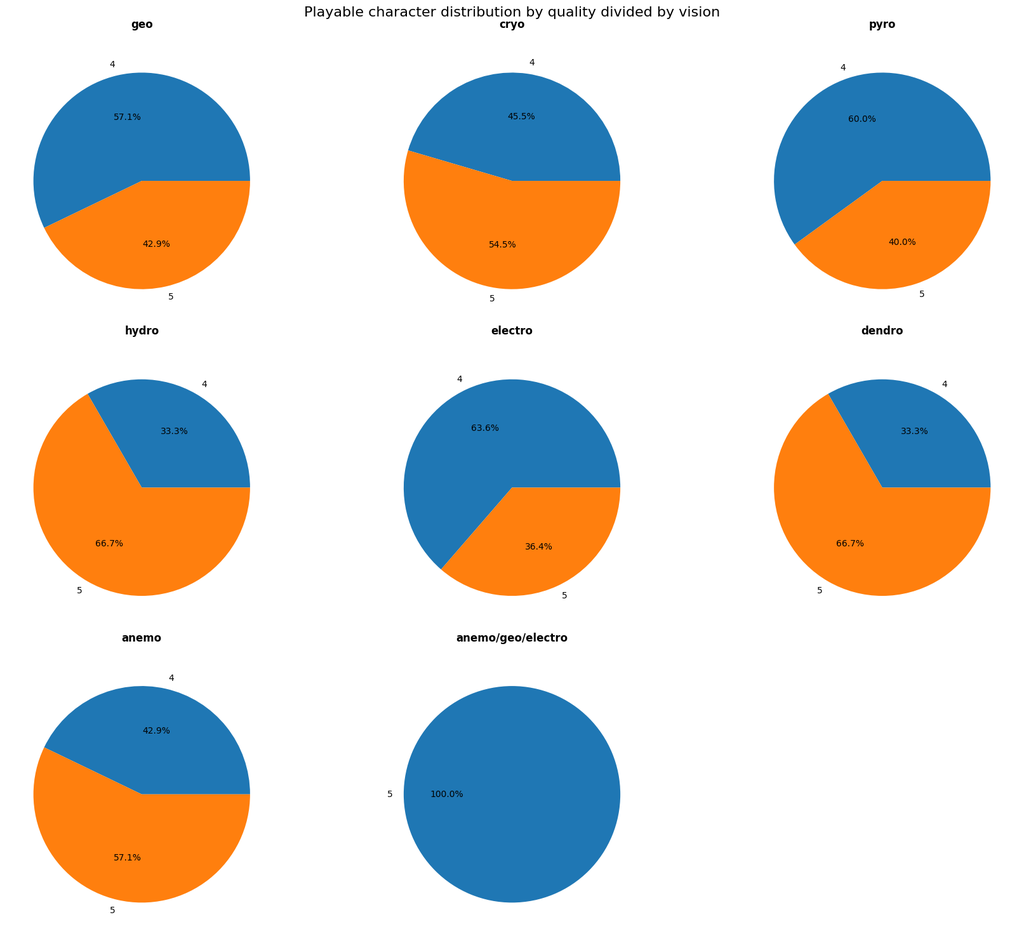

```python
divided_visualisation("quality", "vision")
```

## Misc

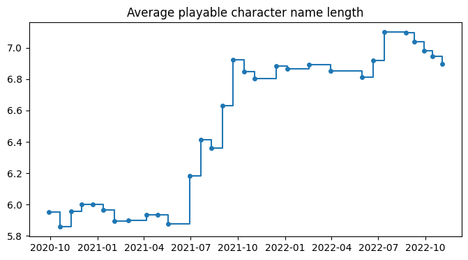

```python
avg_name_length_per_date = []

for date in df.sort_values("release", ascending=False)["release"].unique():
    avg_name_length_per_date.append((date, df[df.release <= date]["name"][df.name != "traveller"].apply(len).mean()))

avg_name_length_per_date.reverse()
avg_name_length_per_date = np.array(avg_name_length_per_date)
x_axis = list(map(dt.datetime.strptime, avg_name_length_per_date[:,0], avg_name_length_per_date.shape[0] * ["%Y-%m-%d"]))
y_axis = list(map(float, avg_name_length_per_date[:,1]))

f = plt.figure()
f.set_figwidth(8)
f.set_figheight(4)

plt.step(x_axis, y_axis, marker="o", markersize=4, where="post")
plt.title("Average playable character name length")
plt.show()
```